# Información de Barrios

Marc Hurtado

2024-04-18

Para realizar esta recogida de información, es necesario usar las siguientes librerías:

`dplyr`: Para la manipulación de datos `tidyr`: Para la manipulación de datos, creación de tablas `sf`: Para la manipulación de datos geográficos, determinar que puntos estan dentro de los barrios `jsonlite`: Para la manipulación de datos `arrow`: Para la manipulación de datos, en nuestro caso para la lectura de ficheros parquet `knir`: Para mostrar la información de una forma más visual.

```r
library(dplyr)
library(tidyr)
library(sf)
library(jsonlite)
library(arrow)
library(knitr)
library(ggplot2)
```

# 1 Carga de datos

Todos los datos son obtenidos de la página de datos abiertos del Ayuntamiento de Valècia En este caso, se han descargado los datos de información general de los barrios de València, los datos de las plazas de aparcamiento, los datos de las paradas de taxis y los datos de la red de movilidad reducida, más concretamente de las plazas de aparcamiento.

```r
data_barrios <- read.csv2("../data/barrios_valencia.csv", sep = ";")

data_mob_red <- read.csv("../00_marc/dataTratada/plazas_mobred_geo.csv", sep = ",")

data_parkings <- read.csv("../00_marc/dataTratada/dataParkings.csv", sep = ",")

data_taxis <- read.csv2("../00_marc/dataPre/data_taxis.csv", sep = ";")
```

# 2 Tratamiento de datos

En primer lugar, separamos la columna *geo_point_2d* en dos columnas, *Latitude* y *Longitude*, para poder trabajar con ellas. Para determinar los puntos por las dos coordenadas y no como un objeto geojson.

```r
data_taxis <- tidyr::separate(data_taxis, geo_point_2d, into = c("Latitude", "Longitude"), sep = ",")
data_taxis$Latitude <- as.numeric(data_taxis$Latitude)
data_taxis$Longitude <- as.numeric(data_taxis$Longitude)
```

Función auxiliar para obtener los polígonos de los barrios, dado un objeto geojson.

```r
obtener_poligonos <- function(df){
  polygons <- lapply(df$geo_shape, function(x) st_read(x, quiet = TRUE))

  # Combina todos los objetos sf en un solo objeto sf
  polygons_barrios <- do.call(rbind, polygons)

  polygons_barrios$Nombre <- df$Nombre
  return(polygons_barrios)
}
```

Obtenemos los polígonos de los barrios.

```r
poligons_barrios <- obtener_poligonos(data_barrios)
poligons_barrios
```

```
## Simple feature collection with 88 features and 1 field
## Geometry type: POLYGON
## Dimension:     XY
## Bounding box:  xmin: -0.432535 ymin: 39.27893 xmax: -0.2753685 ymax: 39.56659
## Geodetic CRS:  WGS 84
## First 10 features:
##                          geometry          Nombre
## 1  POLYGON ((-0.3812389 39.454... LA CREU COBERTA
## 2  POLYGON ((-0.3983043 39.454...       CAMI REAL
## 3  POLYGON ((-0.3360548 39.426...        LA PUNTA
## 4  POLYGON ((-0.4265075 39.495...       BENIMAMET
## 5  POLYGON ((-0.3576153 39.494...    SANT LLORENS
## 6  POLYGON ((-0.388886 39.5002...  CIUTAT FALLERA
## 7  POLYGON ((-0.4068789 39.472...       NOU MOLES
## 8  POLYGON ((-0.4116537 39.465...         LA LLUM
## 9  POLYGON ((-0.3315104 39.485...   LA MALVA-ROSA
## 10 POLYGON ((-0.3691164 39.487...        MORVEDRE
```

# 3 Obtención de los Datos

## 3.1 Paradas de Movilidad Reducida

Ahora, realizamos un bucle que recorra todas las filas de la tabla de plazas de aparcamiento para personas de movilidad reducida (ya que cada fila es un lugar donde hay plazas) y determine en que barrio se encuentra cada una de ellas. Para ello, utilizamos la función *st_within* de la librería *sf*, que nos permite determinar si un punto está dentro de un polígono.

```r
plazas <- data.frame()
# Iterate over each plaza
for (pl in 1:nrow(data_mob_red)) {
  point <- st_point(c(as.numeric(data_mob_red$longitud[pl]), as.numeric(data_mob_red$latitud[pl])), dim = "XY")
  #longitud y latitud porque los poligonos de los barrios estan en ese orden
  b <- unlist(st_within(point, poligons_barrios$geometry))

  if (length(b) > 0) {
    plazas <- rbind(plazas, data.frame(
      id_plaza = data_mob_red$id_plaza[pl],
      plazas_mob = data_mob_red$n_plazas[pl],
      barrio = poligons_barrios$Nombre[b]
    ))
  } else {
    plazas <- rbind(plazas, data.frame(
      id_plaza = NA,
      plazas_mob = NA,
      barrrio = "OTRO"
    ))
  }
}
```

Relizamos una agregación de las plazas de aparcamiento para personas de movilidad reducida por barrio.

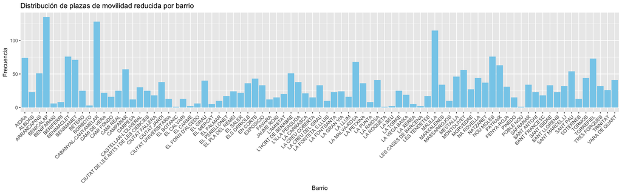

```r
resultado_plazas_mob <- aggregate(plazas_mob ~ barrio, data = plazas, FUN=sum)

ggplot(resultado_plazas_mob, aes(x = barrio, y = plazas_mob)) +
  geom_bar(stat = "identity", fill = "skyblue") +
  theme(axis.text.x = element_text(angle = 45, hjust = 1)) +
  labs(title = "Distribución de plazas de movilidad reducida por barrio",
       x = "Barrio",
       y = "Frecuencia")
```

```r
kable(resultado_plazas_mob)
```

| barrio | plazas_mob |
| --- | --- |
| AIORA | 74 |
| ALBORS | 23 |
| ARRANCAPINS | 51 |
| BENICALAP | 135 |
| BENIFARAIG | 6 |
| BENIFERRI | 8 |
| BENIMACLET | 76 |
| BENIMAMET | 71 |
| BETERO | 25 |
| BORBOTO | 3 |
| CABANYAL-CANYAMELAR | 128 |
| CAMI DE VERA | 22 |
| CAMI FONDO | 16 |
| CAMI REAL | 25 |
| CAMPANAR | 57 |
| CARPESA | 12 |
| CASTELLAR-L’OLIVERAL | 30 |
| CIUTAT DE LES ARTS I DE LES CIENCIES | 25 |
| CIUTAT FALLERA | 18 |
| CIUTAT JARDI | 38 |
| CIUTAT UNIVERSITARIA | 13 |
| EL BOTANIC | 1 |
| EL CALVARI | 13 |
| EL CARME | 2 |
| EL FORN D’ALCEDO | 6 |
| EL GRAU | 40 |
| EL MERCAT | 5 |
| EL PALMAR | 10 |
| EL PERELLONET | 17 |
| EL PLA DEL REMEI | 24 |

[output cut: 53 more lines]

## 3.2 Paradas de Parkings Públicos

Repetimos el mismo procedimiento pero ahora para los parkings públicos.

```r
parkings <- data.frame()

for (pl in 1:nrow(data_parkings)) {
  point <- st_point(c(as.numeric(data_parkings$Longitude[pl]), as.numeric(data_parkings$Latitude[pl])), dim = "XY")
  #longitud y latitud porque los poligonos de los barrios estan en ese orden
  b <- unlist(st_within(point, poligons_barrios$geometry))

  if (length(b) > 0) {
    parkings <- rbind(parkings, data.frame(
      id_plaza = data_parkings$Id[pl],
      plazas_parkings = data_parkings$Total.parking.spaces[pl],
      barrio = poligons_barrios$Nombre[b]
    ))
  } else {
    parkings <- rbind(parkings, data.frame(
      id_plaza = NA,
      plazas_parkings = NA,
      barrio = "OTRO"
    ))
  }
}
```

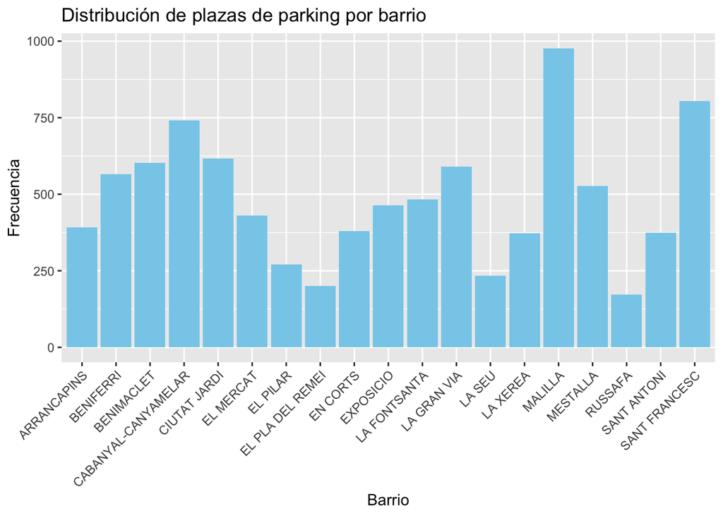

```r
resultado_parkings <- aggregate(plazas_parkings ~ barrio, data = parkings, FUN=sum)

ggplot(resultado_parkings, aes(x = barrio, y = plazas_parkings)) +
  geom_bar(stat = "identity", fill = "skyblue") +
  theme(axis.text.x = element_text(angle = 45, hjust = 1)) +
  labs(title = "Distribución de plazas de parking por barrio",
       x = "Barrio",
       y = "Frecuencia")
```

```r
kable(resultado_parkings)
```

| barrio | plazas_parkings |
| --- | --- |
| ARRANCAPINS | 391 |
| BENIFERRI | 565 |
| BENIMACLET | 603 |
| CABANYAL-CANYAMELAR | 742 |
| CIUTAT JARDI | 617 |
| EL MERCAT | 431 |
| EL PILAR | 270 |
| EL PLA DEL REMEI | 201 |
| EN CORTS | 380 |
| EXPOSICIO | 464 |
| LA FONTSANTA | 483 |
| LA GRAN VIA | 591 |
| LA SEU | 234 |
| LA XEREA | 372 |
| MALILLA | 977 |
| MESTALLA | 527 |
| RUSSAFA | 173 |
| SANT ANTONI | 375 |
| SANT FRANCESC | 805 |

## 3.3 Paradas de Taxis

Y por último, para las paradas de taxis.

```r
taxis <- data.frame()

for (pl in 1:nrow(data_taxis)) {
  point <- st_point(c(as.numeric(data_taxis$Longitude[pl]), as.numeric(data_taxis$Latitude[pl])), dim = "XY")
  #longitud y latitud porque los poligonos de los barrios estan en ese orden
  b <- unlist(st_within(point, poligons_barrios$geometry))

  if (length(b) > 0) {
    taxis <- rbind(taxis, data.frame(
      id_plaza = data_taxis$OBJECTID[pl],
      paradas_taxis = 1,
      barrio = poligons_barrios$Nombre[b]
    ))
  } else {
    taxis <- rbind(taxis, data.frame(
      id_plaza = NA,
      paradas_taxis = 0,
      barrrio = "OTRO"
    ))
  }
}
```

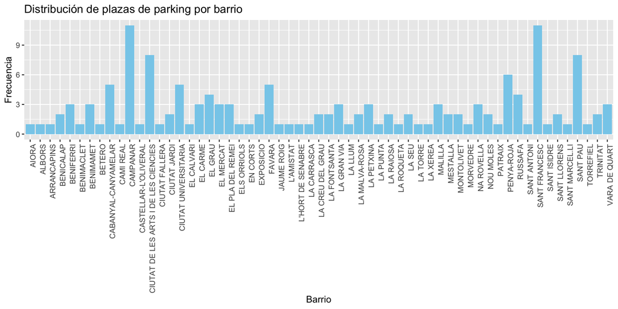

```r
resultado_taxis <- aggregate(paradas_taxis ~ barrio, data = taxis, FUN=sum)

ggplot(resultado_taxis, aes(x = barrio, y = paradas_taxis)) +
  geom_bar(stat = "identity", fill = "skyblue") +
  theme(axis.text.x = element_text(angle = 90, hjust=1)) +
  labs(title = "Distribución de plazas de parking por barrio",
       x = "Barrio",
       y = "Frecuencia")
```

```r
kable(resultado_taxis)
```

| barrio | paradas_taxis |
| --- | --- |
| AIORA | 1 |
| ALBORS | 1 |
| ARRANCAPINS | 1 |
| BENICALAP | 2 |
| BENIFERRI | 3 |
| BENIMACLET | 1 |
| BENIMAMET | 3 |
| BETERO | 1 |
| CABANYAL-CANYAMELAR | 5 |
| CAMI REAL | 1 |
| CAMPANAR | 11 |
| CASTELLAR-L’OLIVERAL | 1 |
| CIUTAT DE LES ARTS I DE LES CIENCIES | 8 |
| CIUTAT FALLERA | 1 |
| CIUTAT JARDI | 2 |
| CIUTAT UNIVERSITARIA | 5 |
| EL CALVARI | 1 |
| EL CARME | 3 |
| EL GRAU | 4 |
| EL MERCAT | 3 |
| EL PLA DEL REMEI | 3 |
| ELS ORRIOLS | 1 |
| EN CORTS | 1 |
| EXPOSICIO | 2 |
| FAVARA | 5 |
| JAUME ROIG | 1 |
| L’AMISTAT | 1 |
| L’HORT DE SENABRE | 1 |
| LA CARRASCA | 1 |
| LA CREU DEL GRAU | 2 |
| LA FONTSANTA | 2 |
| LA GRAN VIA | 3 |
| LA LLUM | 1 |
| LA MALVA-ROSA | 2 |
| LA PETXINA | 3 |
| LA PUNTA | 1 |
| LA RAIOSA | 2 |
| LA ROQUETA | 1 |
| LA SEU | 2 |
| LA TORRE | 1 |
| LA XEREA | 1 |
| MALILLA | 3 |
| MESTALLA | 2 |
| MONTOLIVET | 2 |
| MORVEDRE | 1 |
| NA ROVELLA | 3 |
| NOU MOLES | 2 |
| PATRAIX | 1 |
| PENYA-ROJA | 6 |
| RUSSAFA | 4 |
| SANT ANTONI | 1 |
| SANT FRANCESC | 11 |
| SANT ISIDRE | 1 |
| SANT LLORENS | 2 |
| SANT MARCEL.LI | 1 |
| SANT PAU | 8 |
| TORREFIEL | 1 |
| TRINITAT | 2 |
| VARA DE QUART | 3 |

# 4 Agrupación

Finalmente, agrupamos toda la información en una única tabla, que será en la que se guarde toda la información de los barrios.

```r
info_barrio <- data.frame('barrio' = data_barrios$Nombre)

info_barrio <- merge(info_barrio, resultado_plazas_mob, by = "barrio", all.x = TRUE)
info_barrio <- merge(info_barrio, resultado_taxis, by = "barrio", all.x = TRUE)
info_barrio <- merge(info_barrio, resultado_parkings, by = "barrio", all.x = TRUE)

kable(info_barrio)
```

| barrio | plazas_mob | paradas_taxis | plazas_parkings |
| --- | --- | --- | --- |
| AIORA | 74 | 1 | NA |
| ALBORS | 23 | 1 | NA |
| ARRANCAPINS | 51 | 1 | 391 |
| BENICALAP | 135 | 2 | NA |
| BENIFARAIG | 6 | NA | NA |
| BENIFERRI | 8 | 3 | 565 |
| BENIMACLET | 76 | 1 | 603 |
| BENIMAMET | 71 | 3 | NA |
| BETERO | 25 | 1 | NA |
| BORBOTO | 3 | NA | NA |
| CABANYAL-CANYAMELAR | 128 | 5 | 742 |
| CAMI DE VERA | 22 | NA | NA |
| CAMI FONDO | 16 | NA | NA |
| CAMI REAL | 25 | 1 | NA |
| CAMPANAR | 57 | 11 | NA |
| CARPESA | 12 | NA | NA |
| CASTELLAR-L’OLIVERAL | 30 | 1 | NA |
| CIUTAT DE LES ARTS I DE LES CIENCIES | 25 | 8 | NA |
| CIUTAT FALLERA | 18 | 1 | NA |
| CIUTAT JARDI | 38 | 2 | 617 |
| CIUTAT UNIVERSITARIA | 13 | 5 | NA |
| EL BOTANIC | 1 | NA | NA |
| EL CALVARI | 13 | 1 | NA |
| EL CARME | 2 | 3 | NA |
| EL FORN D’ALCEDO | 6 | NA | NA |
| EL GRAU | 40 | 4 | NA |
| EL MERCAT | 5 | 3 | 431 |
| EL PALMAR | 10 | NA | NA |
| EL PERELLONET | 17 | NA | NA |
| EL PILAR | NA | NA | 270 |

[output cut: 58 more lines]

# 5 Guardado de la información

Para guardar la información, empleamos el formato `csv` y `parquet.` Este último es un formato de almacenamiento de datos columnar, que permite una lectura y escritura más rápida de los datos, además de guardar el esquema de los datos.

```r
write.csv(info_barrio, file = "./dataTratada/info_barrio.csv", row.names = FALSE)

write_parquet(info_barrio,"./dataTratada/info_barrio.parquet")
```